# Cambodia smallholder parametrise

Arata Hidano

1/28/2022

## Parameters

This is a process of parametrising the swIAV model for smallholders.

### Mortality

- Number of smallholders that had at least 1 pigs died in the past 6 months

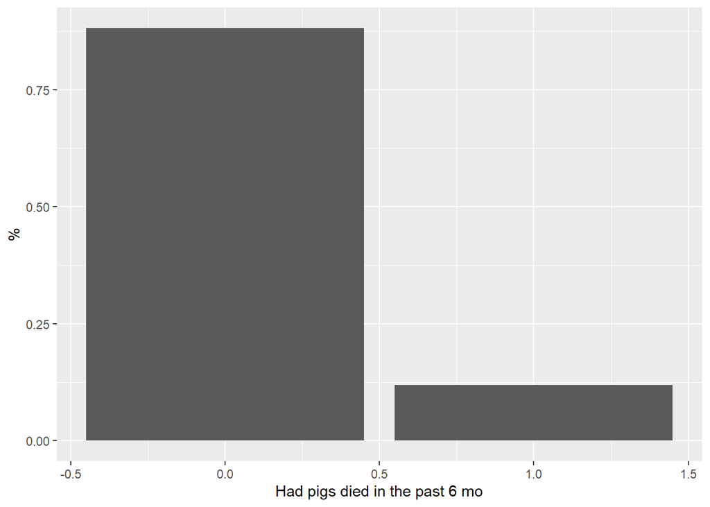

- Number of pigs died in the past 6 months. Note 6 HHs have missing data.

| n_dead | n |
| --- | --- |
| 1 | 2 |
| 2 | 1 |
| 3 | 5 |
| 4 | 2 |
| 5 | 1 |
| 6 | 1 |
| 7 | 1 |
| 8 | 1 |
| 26 | 1 |
| NA | 6 |

- Type and number of pigs died in the past 6 months.  
  Note the data doesn’t tell how many of different pig types died if they had mortality in more than 1 pig category (e.g. sow and boar). Also it doesn’t tell if pigs died in once or at different points in the last 6 months.

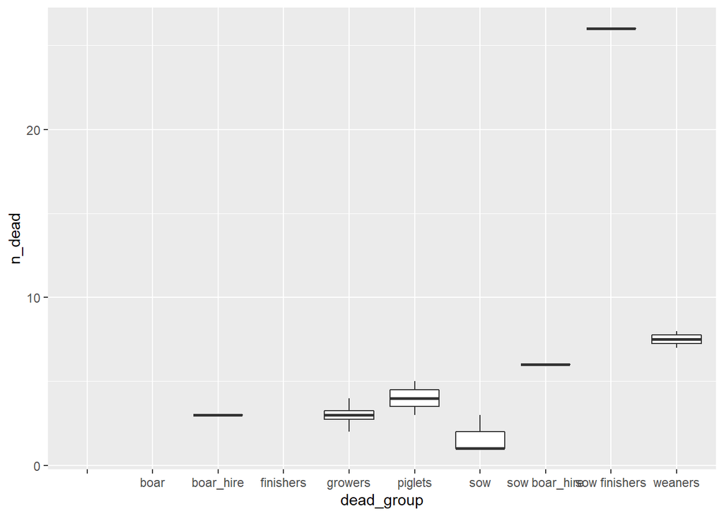

Now we need to know the mortality for different age/type.

#### Piglet

How many farms had piglets died? 3HHs.

| n_dead | n |
| --- | --- |
| 3 | 1 |
| 4 | 1 |
| 5 | 1 |

- And how many farms could have piglets died?  
  Count the number of HHs that had piglets in the past 6 months

Turns out that there are 15 HHs that had piglets in the past 6 months.

| dead_group | n_dead | n |
| --- | --- | --- |
|  | NA | 13 |
| growers | 4 | 1 |
| piglets | 4 | 1 |

But the variable that records if piglets existed in the past 6 months is not reliable because 2 out of 3 HHs that had dead piglets are recorded as ‘didn’t have piglets in the last 6mo’.

| piglet_present | n |
| --- | --- |
|  | 2 |
| present_currently | 1 |

To better capture the number of HHs that had piglets, check HHs that bought or sold piglets in the past 6 mo.  
It turns out that all 9 HHs that bought or sold piglets are also recorded as ‘didn’t have piglets in the last 6mo’.

| piglet_present | n |
| --- | --- |
|  | 9 |

Create a new var `piglet_present2` that represents the presence of piglets in the last 6mo by marking HHs that (1) bought or sold piglets in the past 6mo, or (2) had piglets died in the last 6 mo.

| piglet_present2 | n |
| --- | --- |
| present | 26 |

There are at least 26 HHs that had piglets in the last 6 mo.  
Assuming these records are accurate, probability of having piglets died before weaning is:

```
## [1] 0.1153846
```

#### Weaning to grower stage

How many farms had weaning died? 3HHs.

| n_dead | n |
| --- | --- |
| 7 | 1 |
| 8 | 1 |
| NA | 1 |

- And how many farms could have weaners died?  
  Count the number of HHs that had weaners in the past 6 months

Turns out that there are 25 HHs that had weaners in the past 6 months.

| dead_group | n_dead | n |
| --- | --- | --- |
|  | NA | 22 |
| growers | 3 | 1 |
| growers | 4 | 1 |
| piglets | 4 | 1 |

| weaner_present | n |
| --- | --- |
|  | 3 |

To better capture the number of HHs that had weaners, check HHs that bought or sold weaners in the past 6 mo. It turns out that 119 HHs bought or sold weaners in the past 6 mo and 102 HHs arerecorded as ‘didn’t have piglets in the last 6mo’.

| weaner_present | n |
| --- | --- |
|  | 102 |
| present_currently | 13 |
| present_previously | 4 |

Create a new var `weaner_present2` that represents the presence of weaner in the last 6mo by marking HHs that (1) bought or sold weaners in the past 6mo, or (2) had weaners died in the last 6 mo.

| weaner_present2 | n |
| --- | --- |
| present | 128 |

There are at least 128 HHs that had weaners in the last 6 mo. Assuming these records are accurate, probability of having weaners died before weaning is:

```
## [1] 0.0234375
```

#### Growers

How many farms had growers and finishers? 6 HHs and 2 have missing data for the number of deaths.

| n_dead | n |
| --- | --- |
| 2 | 1 |
| 3 | 2 |
| 4 | 1 |
| NA | 2 |

- And how many farms could have growers died?  
  Count the number of HHs that had growers in the past 6 months

Turns out that there are 61 HHs that had growers in the past 6 months.

| dead_group | n_dead | n |
| --- | --- | --- |
|  | NA | 51 |
| growers | 2 | 1 |
| growers | 3 | 1 |
| growers | NA | 2 |
| piglets | 3 | 1 |
| sow | 1 | 2 |
| sow | 3 | 1 |
| weaners | 7 | 1 |
| weaners | 8 | 1 |

To better capture the number of HHs that had growers, check HHs that bought or sold growers in the past 6 mo. It turns out that 3 HHs bought or sold growers in the past 6 mo and 2 HHs are recorded as ‘didn’t have growers in the last 6mo’.

| grow_present | n |
| --- | --- |
|  | 2 |
| present_currently | 1 |

Create a new var `grow_present2` that represents the presence of growers in the last 6mo by marking HHs that (1) bought or sold growers in the past 6mo, or (2) had growers died in the last 6 mo.

| grow_present2 | n |
| --- | --- |
| present | 65 |

There are at least 65 HHs that had growers in the last 6 mo. Assuming these records are accurate, probability of having growers died before weaning is:

```
## [1] 0.09230769
```

#### Finishers

Just in case check HHs had dead finishers. 2 HHs had finishers died. One HH unknown number. The other lost 26 pigs including sows and finishers, but unknown how many of each. Likely majority was finishers and this is disease outbreak so cannot consider as baseline. Ignore finisher death.

| n_dead | n |
| --- | --- |
| 26 | 1 |
| NA | 1 |

#### Sow

How many HHs lost sows? 6 HHs: 1 HH unknown number, 2 HHs had sows and other type died so cannot tell how many sows died. Others, 1, 1, and 3.

| n_dead | sow_present | n |
| --- | --- | --- |
| 1 |  | 1 |
| 1 | present_currently | 1 |
| 3 |  | 1 |
| 6 | present_currently | 1 |
| 26 |  | 1 |
| NA | present_currently | 1 |

- And how many farms could have sows died?  
  Count the number of HHs that had sows in the past 6 months

Turns out that there are 136 HHs that had sows in the past 6 months.

| dead_group | n_dead | n |
| --- | --- | --- |
|  | NA | 124 |
| boar | NA | 1 |
| growers | 3 | 1 |
| growers | 4 | 1 |
| growers | NA | 1 |
| piglets | 3 | 1 |
| piglets | 4 | 1 |
| piglets | 5 | 1 |
| sow | 1 | 1 |
| sow | NA | 1 |
| sow boar_hire | 6 | 1 |
| weaners | 8 | 1 |
| weaners | NA | 1 |

To better capture the number of HHs that had sows, check HHs that bought or sold sows in the past 6 mo. It turns out that 6 HHs bought or sold sows in the past 6 mo and 0 HHs are recorded as ‘didn’t have sows in the last 6mo’.

| sow_present | n |
| --- | --- |
| present_currently | 6 |

Create a new var `sow_present2` that represents the presence of sows in the last 6mo by marking HHs that (1) bought or sold sow in the past 6mo, or (2) had sow died in the last 6 mo.

| sow_present2 | n |
| --- | --- |
| present | 138 |

There are at least 138 HHs that had sows in the last 6 mo.  
Obviously, the number of HHs that had dead sows is under-reported because if it’s breeding smallholder and lost sows and didn’t restock, then these HHs were not recruited as they don’t have pigs. Assuming these records are accurate, probability of having sows died before weaning is:

```
## [1] 0.04347826
```

In addition to death, there is culling event for sows.

```
##       sow_last_year n_sow sow_s
## 3:67              1     1     1
## 3:78              1     2     1
## 3:138             2     1     1
```

3 HHs sold sows (one each). Rate of replacement per year is:

```
## [1] 23
```

This translates that it takes 23 years for one sow to be replaced and this is not realistic. So clearly this is under-reporting. So cannot use the data to infer this parameter.

### Reproduction

#### Litter size and frequency of farrowing (all HHs)

Information of age at the first mating was not collected. I will collect these info in the village survey in ASF. How many litters are produced per year?

```
##   num_litter        sow_present   n
## 1          0  present_currently   1
## 2          2  present_currently  14
## 3       <NA>                      2
## 4       <NA>  present_currently 120
## 5       <NA> present_previously   1
```

135 HHs have sows now, but 120 missing information for the number of litters. 14 HHs have 2 litters and 1 HH has 0 litter.  
Did these HHs with missing data sell, or currently have any piglets in the last 6 mo?

```
##   piglet_present2 n_piglet piglet_p piglet_s   n
## 1         present        0       18     <NA>   1
## 2         present        0        2        4   1
## 3         present        0        2     <NA>   1
## 4         present        0     <NA>       10   3
## 5         present        0     <NA>        5   1
## 6         present        0     <NA>     <NA>   2
## 7            <NA>        0     <NA>     <NA> 114
```

Among HHs that have sows but missing data for the number of litters per year, 5 HHs sold piglets in the last 6 months. Among these, 3 HHs sold 10 piglets.  
- Check how many sows they have.

```
##       n_sow sow_s dead_group n_dead
## 3:2       2  <NA>                NA
## 3:126     1  <NA>                NA
## 3:127     2  <NA>                NA
```

Among these 3 HHs, 2 HHs have 2 sows and 1 HH has 1 sow. It’s difficult to know if these 10 piglets were from 1 sow or 2 sows. Assume it’s 1 sow.  
- Now let’s turn to movement data and if this data contains information about the piglet selling.

```
##      freq piglets
## 1 1yearly      10
```

```
##                                       egoID
## 1 uuid:f6be3d92-5650-4113-bbcf-28f60e480374
```

Only 1 data point is recorded; 1 HH sold 10 piglets (once a year).  
- Check if this HH sells anything else.

```
##   sows boars boars_hire piglets weaners growers finishers pigs_unknown_type
## 1   NA    NA         NA      10      NA      NA        NA                NA
```

```
##     n_sow n_boar n_piglet n_weaner n_grower n_finisher piglet_s weaner_s
## 3:2     2      0        0        3        0          0       10     <NA>
##     grower_s finisher_s piglet_p weaner_p sow_p
## 3:2     <NA>         NA     <NA>       NA  <NA>
```

Only piglets. This HH has 3 weaners and didn’t purchase any piglet/weaner. Nor, purchased any sows in the last 6 months. So there were 2 sows in the last 6 months. This means maybe one sow farrowed all 13 piglets? And farrow once a year(update this info).

How about other HHs that missing # litter but have sows - can I infer # litter based on movement data?

```
## [1] egoID     piglets   weaners   growers   finishers freq
## <0 rows> (or 0-length row.names)
```

Unfortunately, there is no more records of piglet selling in the movement data.

- Now turn to weaner selling data.  
  Many HHs sold weaners but they don’t have the litter number data.

```
##    weaner_present2 n_weaner weaner_p weaner_s num_litter  n
## 1          present        0        1     <NA>       <NA>  7
## 2          present        0        2     <NA>       <NA> 10
## 3          present        0        3     <NA>       <NA>  4
## 4          present        0        4     <NA>       <NA>  3
## 5          present        0        8     <NA>       <NA>  1
## 6          present        0       10     <NA>       <NA>  1
## 7          present        0       13     <NA>       <NA>  1
## 8          present        0       16     <NA>       <NA>  1
## 9          present        0       21     <NA>       <NA>  2
## 10         present        0       24     <NA>       <NA>  1
## 11         present        0       29       19       <NA>  1
## 12         present        0       NA        1       <NA>  3
## 13         present        0       NA       10       <NA> 10
## 14         present        0       NA       11       <NA>  2
```

[output cut: 29 more lines]

Check if HHs that sold weaners have selling data, to see if I can infer the litter number based on the movement data.  
1. First, check those sold only once whatever the pig type was.

```
##    piglets weaners growers finishers       freq
## 1       NA       8      NA        NA   6monthly
## 2       NA       4      NA        NA first_time
## 3       NA       9      NA        NA first_time
## 4       NA      10      NA        NA   6monthly
## 5       NA      25      NA        NA   6monthly
## 6       NA       4      NA        NA first_time
## 7       NA       8      NA        NA first_time
## 8       NA      10      NA        NA   6monthly
## 9       NA      17      NA        NA first_time
## 10      NA      30      NA        NA   6monthly
## 11      NA      10      NA        NA   6monthly
## 12      NA      10      NA        NA first_time
## 13      NA       1      NA        NA first_time
## 14      NA      20      NA        NA   6monthly
## 15      NA       5      NA        NA first_time
## 16      NA       7      NA        NA first_time
## 17      NA      12      NA        NA first_time
## 18      NA       2      NA        NA first_time
## 19      NA       8      NA        NA    1yearly
## 20      NA       9      NA        NA first_time
## 21      NA      10      NA        NA   6monthly
## 22      NA      10      NA        NA   6monthly
## 23      NA       7      NA        NA first_time
## 24      NA      10      NA        NA first_time
## 25      NA       6      NA        NA first_time
## 26      NA      10      NA        NA first_time
## 27      NA       8      NA        NA first_time
## 28      NA       4      NA        NA   6monthly
## 29      NA       1      NA        NA first_time
```

For these HHs, it’s only weaners that they sold. So `freq` gives an idea about the frequency of piglet productions. Extract this and add to the original data.

```
##    n_sow n_piglet n_weaner n_grower n_finisher weaner_s       freq litter_size
## 1      0        0        0        0          0        8   6monthly        <NA>
## 2      1        0        0        0          0        4 first_time        <NA>
## 3      2        0        9        0          0        9 first_time        <NA>
## 4      4        0       20        0          0       10   6monthly        <NA>
## 5      5        0        0        0          0       25   6monthly        <NA>
## 6      2        0        2        0          0        4 first_time        <NA>
## 7      2        0        0        0          0        8 first_time        <NA>
## 8      1        0        0        0          0       10   6monthly        <NA>
## 9      1        0        0        0          0       17 first_time        <NA>
## 10     3        0        0        0          0       30   6monthly        <NA>
## 11     2        0        0        0          0       10   6monthly        <NA>
## 12     4        0        0        0          0       10 first_time        <NA>
## 13     0        0        0        1          0        1 first_time        <NA>
## 14     4        0        0        2          0       20   6monthly        <NA>
## 15     1        0        0        1          0        5 first_time        <NA>
## 16     7        0        0        0          0        7 first_time        <NA>
## 17     6        0        0        0          0       12 first_time        <NA>
## 18     2        0        0        0          0        2 first_time        <NA>
## 19     2        0        0        0          0        8    1yearly        <NA>
## 20     1        0        0        0          0        9 first_time        <NA>
## 21     2        0        0        0          0       10   6monthly        <NA>
## 22     1        0        0        0          0       10   6monthly        <NA>
## 23     1        0        0        0          0        7 first_time        <NA>
## 24     1        0        0        0          0       10 first_time        <NA>
## 25     1        0        0        0          0        6 first_time        <NA>
## 26     2        0        0        0          0       10 first_time        <NA>
## 27     2        0        0        0          0        8 first_time        <NA>
## 28     3        0        0        0          0        4   6monthly        <NA>
## 29     2        0        0        0          0        1 first_time        <NA>
```

- First, update those with only 1 sows. Litter size all NA. None sold piglets.

```
##    n_sow n_piglet n_grower n_finisher weaner_s       freq n_dead dead_group
## 1      0        0        0          0        8   6monthly     NA
## 2      1        0        0          0        4 first_time     NA
## 3      1        0        0          0       10   6monthly     NA
## 4      1        0        0          0       17 first_time     NA
## 5      0        0        1          0        1 first_time      3        sow
## 6      1        0        1          0        5 first_time     NA
## 7      1        0        0          0        9 first_time     NA
## 8      1        0        0          0       10   6monthly     NA
## 9      1        0        0          0        7 first_time     NA        sow
## 10     1        0        0          0       10 first_time     NA    weaners
## 11     1        0        0          0        6 first_time     NA
```

```
##   n_sow sow_s weaner_s       freq n_dead dead_group
## 1     1  <NA>       17 first_time     NA
```

I can assume that the litter size equals to the number of weaners sold , except that with 17 weaners. They may have 2 sows before?  
Also that they don’t currently have piglet and weaner means that they produce 1 litter per year. But not sure so keep NA for those sold for the first time for this seller.

- Next update those with more than 1 sows.  
  Update the litter size and number of litters as well as creating `estimated_farrow` which indicates the frequency of farrows in the last 6 months.This estimation is based on the frequency of selling piglet/weaners and the current number of pigs.

Note that it doesn’t show below but none of these HHs purchased piglets/weaners in the last 6 months.

```
##    n_sow n_piglet n_weaner n_grower weaner_s       freq sow_p n_dead
## 1      2        0        9        0        9 first_time  <NA>     NA
## 2      4        0       20        0       10   6monthly  <NA>     NA
## 3      5        0        0        0       25   6monthly  <NA>     NA
## 4      2        0        2        0        4 first_time  <NA>     NA
## 5      2        0        0        0        8 first_time  <NA>     NA
## 6      3        0        0        0       30   6monthly  <NA>     NA
## 7      2        0        0        0       10   6monthly  <NA>     NA
## 8      4        0        0        0       10 first_time  <NA>     NA
## 9      4        0        0        2       20   6monthly  <NA>     NA
## 10     7        0        0        0        7 first_time  <NA>     NA
## 11     6        0        0        0       12 first_time     2     NA
## 12     2        0        0        0        2 first_time  <NA>     NA
## 13     2        0        0        0        8    1yearly  <NA>     NA
## 14     2        0        0        0       10   6monthly  <NA>     NA
## 15     2        0        0        0       10 first_time  <NA>     NA
## 16     2        0        0        0        8 first_time  <NA>     NA
## 17     3        0        0        0        4   6monthly  <NA>     NA
## 18     2        0        0        0        1 first_time     1     NA
```

End of updating info for HHs that purchased any type of pigs only once in the past 6 months.  
2. Now move onto HHs sold more than once.

```
## # A tibble: 40 x 7
##    egoID                   ID_n2_egoID piglets weaners growers finishers freq
##    <chr>                         <int>   <int>   <int>   <int>     <int> <chr>
##  1 uuid:0289c484-d892-4a1~           1      NA       9      NA        NA 6month~
##  2 uuid:0289c484-d892-4a1~           1      NA       4      NA        NA first_~
##  3 uuid:101cc2cd-80ed-4b6~           2      NA       6      NA        NA first_~
##  4 uuid:101cc2cd-80ed-4b6~           2      NA      10      NA        NA 6month~
##  5 uuid:19af9c3b-5920-402~           3      NA      23      NA        NA 6month~
##  6 uuid:19af9c3b-5920-402~           3      NA      27      NA        NA 6month~
##  7 uuid:28f03fc2-5967-47f~           4      NA       1      NA        NA first_~
##  8 uuid:28f03fc2-5967-47f~           4      NA       1      NA        NA first_~
##  9 uuid:28f03fc2-5967-47f~           4      NA      10      NA        NA 6month~
## 10 uuid:3a460a94-8752-490~           5      NA      10      NA        NA first_~
## 11 uuid:3a460a94-8752-490~           5      NA       6      NA        NA first_~
## 12 uuid:3a460a94-8752-490~           5      NA       5      NA        NA first_~
```

[output cut: 28 more lines]

Then cross-check with the main data to see how many sows they have. As below, none of them have data for litter size and number of litters. Also they have no piglets at this moment.

```
##    n_sow n_weaner n_grower n_finisher weaner_s grower_s finisher_s ID_n2_egoID
## 1      2        0        0          0       13     <NA>         NA           1
## 2      2        0        0          0       16     <NA>         NA           2
## 3     11        0        0          0       50     <NA>         NA           3
## 4      3        0        0          0        1     <NA>         NA           4
## 5      4        0        0          0       21     <NA>         NA           5
## 6      5       10        0          0       18     <NA>         10           6
## 7      4        0        0          0       12     <NA>         NA           7
## 8      6        0        0          0       25     <NA>         NA           8
## 9      1        0        0          0       10     <NA>         NA           9
## 10     4        0        0          0       14     <NA>         NA          10
## 11     4        0        0          0        9     <NA>         NA          11
## 12     4        0        9          0       10     <NA>          5          12
## 13     2        0        4          0       20     <NA>         NA          13
## 14     3        0        0          0       25     <NA>         NA          14
## 15     1        0        0          0        8     <NA>         NA          15
## 16     2        0        0          0       22     <NA>         NA          16
## 17     2        0        0          0       11     <NA>         NA          17
## 18     2        0        4          0       18     <NA>         NA          18
## 19     2        0        0          0       11     <NA>         NA          19
## 20     4        0        1          0       16     <NA>         NA          20
```

Update `litter_size` and `num_litter` manually.

So now estimation of litter size and frequency was done for those sold piglet and weaners. Check how many missing among those have piglet or weaner. Why these HHs were not captured by the procedure above?  
Because no movement data exists for these HHs.

```
##    n_sow n_piglet n_weaner n_grower n_finisher piglet_s weaner_s piglet_p
## 1      8        0        5        5          0     <NA>       40     <NA>
## 2      0        0        5        5          0     <NA>     <NA>     <NA>
## 3      2        0        2        0          0     <NA>        4     <NA>
## 4      3        0        3        0          0     <NA>       12     <NA>
## 5      0        0       10       13          0     <NA>       10     <NA>
## 6      2        0        3        0          0        5     <NA>     <NA>
## 7      1        0        2        0          0        4     <NA>        2
## 8      2        0       13        0         14     <NA>     <NA>     <NA>
## 9      4       13        0        0          0     <NA>     <NA>     <NA>
## 10     3        0        9        0          0     <NA>     <NA>     <NA>
## 11     2       11        0        0          0     <NA>     <NA>     <NA>
## 12     1        8        0        0          0     <NA>     <NA>     <NA>
## 13     3        7        0       16          0     <NA>     <NA>     <NA>
## 14     1        5        0        0          0     <NA>     <NA>     <NA>
```

[output cut: 45 more lines]

Update `litter_size` manually. Difficult to estimate `num_litter` because we don’t know how often they sold.

Now I did almost everything I could do to fill missing data as much as possible for `litter_size` and `num_litter`.

#### Mating and AI use (all HHs)

Check how often AI or boar service was used.  
First check HHs that purchased AI, and if they also hired boar, how many farrowing occurred.  
Create `estimated_ai_success` which shows the probability of conception by one AI.

```
##    n_sow ai_purchased n_boar boar_p boar_h sow_p estimated_farrow n_piglet
## 1      2            2      0   <NA>     NA  <NA>               NA        0
## 2      2            1      0   <NA>     NA  <NA>               NA        0
## 3      4            7      0   <NA>     NA     3               NA        2
## 4      2            2      0   <NA>     NA  <NA>               NA        0
## 5      3            1      0   <NA>     NA  <NA>               NA        0
## 6      3            3      0   <NA>     NA  <NA>               NA        0
## 7      2            1      0   <NA>     NA  <NA>               NA        0
## 8      3            4      0   <NA>     NA  <NA>               NA        8
## 9      2            1      0   <NA>     NA  <NA>               NA        0
## 10     4            6      0   <NA>     NA  <NA>               NA        0
## 11     1            1      0   <NA>     NA  <NA>               NA        0
## 12     7            1      0   <NA>      1  <NA>               NA        0
## 13     4            1      0   <NA>     NA  <NA>               NA        0
##    n_weaner
## 1         0
## 2         0
## 3         0
## 4         0
## 5         0
## 6         0
## 7         2
## 8         0
## 9         0
## 10        0
## 11        0
## 12        0
## 13        0
```

Next check HHs that used boar service. (note none of these HHs have boar)  
Create `estimated_mating_success` to represent the conception probability by boar. Note none bought boars. Also no one has data for litter_size.

```
##    n_sow boar_h n_piglet n_weaner n_grower n_finisher piglet_s weaner_s
## 1      0      2        0        0        0          0     <NA>        8
## 2      1      1        0        0        0          0     <NA>        8
## 3      1      1        6        0        0          0     <NA>     <NA>
## 4      1      1        0        0        0          0     <NA>     <NA>
## 5      1      1        0        9        0          0     <NA>     <NA>
## 6      1      1        0        0        0          0     <NA>        4
## 7      1      1        0        0        0          0     <NA>     <NA>
## 8      1      1        0        0        0          0     <NA>     <NA>
## 9      1      1        0        0        0          0     <NA>     <NA>
## 10     1      1        0        0        0          0     <NA>     <NA>
## 11     1      1        0        0        1          0     <NA>     <NA>
## 12     1      1        0        0        0          0     <NA>        9
## 13     1      1        5        0        0          0     <NA>     <NA>
## 14     1      1        0        0        0          0     <NA>     <NA>
```

[output cut: 58 more lines]

#### Gilt introduction

The data does not specify whether it was gilt or just fattening grower that was purchased. So I need to make assumptions that (1) growers purchased by breeding HHs were gilts unless they do fattening as well, (2) check frequency if that helps.

```
## # A tibble: 4 x 3
## # Groups:   egoID [3]
##   egoID                                     growers freq
##   <chr>                                       <int> <chr>
## 1 uuid:7930de93-3357-44f0-bb00-0a2a39127715       4 6monthly
## 2 uuid:f6f178c2-d631-4cab-9d1a-21c375c45939       2 first_time
## 3 uuid:00a4cb81-623b-4874-a679-6c94d3a29b54       4 first_time
## 4 uuid:00a4cb81-623b-4874-a679-6c94d3a29b54       1 first_time
```

```
##                                          ID n_sow n_piglet n_grower n_finisher
## 1 uuid:7930de93-3357-44f0-bb00-0a2a39127715     0        0        9          0
## 2 uuid:f6f178c2-d631-4cab-9d1a-21c375c45939     0        0        0          0
## 3 uuid:00a4cb81-623b-4874-a679-6c94d3a29b54     4        0        0          0
##   piglet_s weaner_s grower_s finisher_s grower_p boar_h n_dead dead_group
## 1     <NA>     <NA>     <NA>          7        4     NA     NA
## 2     <NA>     <NA>     <NA>         NA        2     NA     NA
## 3     <NA>     <NA>     <NA>         NA        4     NA     NA
```

3 Hhs bought growers (1HH bought twice in total 5 growers but only have 4, although they didn’t sell anything nor died). This is the only HH that bought growers for breeding reason.  
How about weaners? Do HHs buy weaners to make it sow?  
None of them sold piglet or weaner yet. None have weaners or finishers. None purchased growers or piglets.  
This means purchased weaners are present as grower or sows.

```
## # A tibble: 76 x 3
## # Groups:   egoID [59]
##    egoID                                     weaners freq
##    <chr>                                       <int> <chr>
##  1 uuid:f8c76138-0910-436c-a70e-519997bd93ee      16 first_time
##  2 uuid:b25c1a96-11cf-4c7b-90cd-84e977e6035f      13 first_time
##  3 uuid:64d2c7a4-e6f0-4dc0-84f4-1196d0431bc1       6 first_time
##  4 uuid:21c452c2-a9a3-47d6-a38d-8061cc5ecd4b       9 first_time
##  5 uuid:7930de93-3357-44f0-bb00-0a2a39127715       5 6monthly
##  6 uuid:ee3cb3e1-329b-4626-8ede-c23b7f68c767      13 6monthly
##  7 uuid:5bfd454f-dc6a-4f83-8017-a4723dafe9ad      10 first_time
##  8 uuid:5bfd454f-dc6a-4f83-8017-a4723dafe9ad       5 first_time
##  9 uuid:d48b2dbb-f405-4152-95cc-2f708af6943c       7 first_time
## 10 uuid:d48b2dbb-f405-4152-95cc-2f708af6943c      10 first_time
## # ... with 66 more rows
```

```
##    n_sow n_piglet n_grower finisher_s boar_h weaner_p                    type
## 1      1        0       16         16     NA       16                 growing
## 2      2        0       13         NA      1       13                  f_to_f
## 3      1        0       21          5     NA       21        breeding growing
## 4      1        0        2         NA     NA        1                 growing
## 5      3        0        0         NA     NA        3                breeding
## 6      2        0        0         NA     NA        2                breeding
## 7      3        0        8          6     NA        8                 growing
## 8      2        0       20         NA     NA       21    growing f_to_f other
## 9      2        0       14         18     NA       24                 growing
## 10     2        0        0         NA     NA        4                breeding
## 11     2        0        0         NA     NA        2                breeding
## 12     2        0        0         NA     NA        2                breeding
## 13     4        0        0         NA     NA        4                breeding
## 14     3        0        0         NA     NA        3                breeding
```

[output cut: 16 more lines]

It looks like most of HHs bought weaners to use them as sows are newly starting HHs. This makes it difficult to know the replacement rate of sows. So instead check the move-out data that sold sows.

```
## # A tibble: 3 x 3
## # Groups:   egoID [3]
##   egoID                                      sows alter_type
##   <chr>                                     <int> <chr>
## 1 uuid:b7010d64-f875-4c28-bdd8-4e72031b8929     1 trader
## 2 uuid:e8d1a5ba-d9df-4e8b-ab7f-0ee61ea9dc57     1 butcher
## 3 uuid:96fe530d-b03d-4bad-8c69-b5b972f435d0     1 sml_hh
```

```
##   n_sow n_piglet n_weaner n_grower sow_s boar_h piglet_p weaner_p grower_p
## 1     2        0        0        0     1      1     <NA>       NA     <NA>
## 2     1        0        0        0     1      1     <NA>        1     <NA>
## 3     1        5        0        0     1      1     <NA>       NA     <NA>
##   sow_p     type alter_type
## 1  <NA> breeding    butcher
## 2  <NA> breeding     trader
## 3  <NA> breeding     sml_hh
```

```
##   n_sow n_boar n_piglet n_weaner n_grower n_finisher total death_presence
## 1     2      0        0        0        0          0     2             no
## 2     1      0        0        0        0          0     1             no
## 3     1      0        5        0        0          0     6             no
##   n_dead dead_group                         symptom av_num_fatten
## 1     NA                                      other            NA
## 2     NA            diarrhoea inappetence nose eyes            NA
## 3     NA                      inappetence diarrhoea            NA
##   av_num_fatten_lasty death_presence_bin litter_size num_litter sow_p boar_p
## 1                  NA                  0          11          2  <NA>   <NA>
## 2                  NA                  0          NA       <NA>  <NA>   <NA>
## 3                  NA                  0           5       <NA>  <NA>   <NA>
##   boar_h ai_purchased piglet_p weaner_p grower_p finisher_p sow_s boar_s boar_l
## 1      1         <NA>     <NA>       NA     <NA>       <NA>     1   <NA>   <NA>
## 2      1         <NA>     <NA>        1     <NA>       <NA>     1   <NA>   <NA>
```

[output cut: 21 more lines]

From here, purchasing weaners for replacement purpose is extremly rare and usually HHs raise replacement sows from one of the piglets. A very small fraction of HHs may purchase replacement gilts. I need to use literature value for the culling age.

3 HHs sold sows; 2 sold to butcher or trader, 1 sold to other HHs. 1 sold sow and purchased a weaner that became a sow. So it’s difficult to know at which age sows were sold. But 2 HHs sold during 6 mo among all HHs with sows may indicate the rate of culling. Also replacement does not happen immediately.

- Conclusion: Cannot estimate the age of culling for sows, cannot estimate the replacement rate. However, many HHs raise their own piglets to make sows. Newly starting HHs buy weaners, rather than growers, to raise sows.

### Typology

Based on breeding and growing practices, categorize breeding and fattening HHs into subgroups.

#### Breeding

Select all HHs that have sows and check those recorded as growing.  
These HHs have sows but they don’t breed (no AI or boar use).

```
##      type n_sow n_piglet n_weaner n_grower ai_purchased boar_h piglet_s
## 1 growing     1        0        0       16         <NA>     NA     <NA>
## 2 growing     2        0        0        0         <NA>     NA     <NA>
## 3 growing     1        0        0        2         <NA>     NA     <NA>
## 4 growing     3        0        0        8         <NA>     NA     <NA>
## 5 growing     2        0        0       14         <NA>     NA     <NA>
## 6 growing     1        0        0       10         <NA>     NA     <NA>
##   weaner_s piglet_p weaner_p
## 1     <NA>     <NA>       16
## 2     <NA>     <NA>       NA
## 3     <NA>     <NA>        1
## 4     <NA>     <NA>        8
## 5     <NA>     <NA>       24
## 6       19     <NA>       29
```

Next group HHs with sows but only recently started raising (i.e. no sow present last year) None of them sold piglets. First check those sold weaners already. They didn’t buy piglets.

```
##       type n_sow n_piglet n_weaner n_grower ai_purchased boar_h weaner_s
## 1 breeding     2        0        9        0         <NA>      1        9
## 2  growing     1        0        0       10         <NA>     NA       19
## 3 breeding     7        0        0        0            1      1        7
##   weaner_p                      Group
## 1       NA                       <NA>
## 2       29 Fattening_withSows_nobreed
## 3       NA                       <NA>
```

Out of 3 Hhs, 2 started breeding this year. The other one is growing.  
Check those didn’t sell weaners yet. None bought growers. 2 bought sows, categorized as New_breeding. None have weaners or growers.

```
##        type n_sow n_piglet ai_purchased boar_h piglet_p weaner_p
## 1  breeding     2        0         <NA>     NA     <NA>        2
## 2  breeding     4        0         <NA>      1     <NA>       NA
## 3  breeding     3        0         <NA>     NA     <NA>       NA
## 4  breeding     2        0            2     NA     <NA>       NA
## 5  breeding     2        0         <NA>     NA     <NA>        4
## 6  breeding     2        0         <NA>     NA     <NA>        2
## 7  breeding     2        0         <NA>     NA     <NA>        2
## 8  breeding     4        0         <NA>     NA     <NA>        4
## 9  breeding     3        0         <NA>     NA     <NA>        3
## 10 breeding     1        0         <NA>     NA     <NA>        1
## 11 breeding     2        0         <NA>     NA     <NA>        2
## 12 breeding     2        0         <NA>     NA        2       NA
## 13 breeding     1        0         <NA>     NA     <NA>       NA
## 14 breeding     2        0         <NA>     NA     <NA>       NA
## 15 breeding     3        0         <NA>     NA     <NA>        3
## 16 breeding     2        0         <NA>     NA     <NA>       NA
## 17 breeding     1        5         <NA>      1     <NA>       NA
## 18 breeding     1        0         <NA>     NA     <NA>        1
## 19 breeding     2        0         <NA>     NA     <NA>        2
## 20 breeding     2        0         <NA>     NA     <NA>        2
## 21 breeding     2        0         <NA>     NA     <NA>        2
## 22 breeding     5        0         <NA>      1     <NA>        4
## 23 breeding     1        0         <NA>      1     <NA>       NA
## 24 breeding     2        0         <NA>     NA     <NA>        2
## 25 breeding     1        0         <NA>     NA     <NA>        1
## 26 breeding     1        0         <NA>     NA     <NA>        1
## 27 breeding     2        0         <NA>     NA     <NA>        2
```

Those purchased piglet or weaners raised them as sows; categorize them New_breeding. Those didn’t purchase piglet or weaners, also New_breeding.

```
##       type n_sow n_piglet ai_purchased boar_h piglet_p weaner_p
## 1 breeding     4        0         <NA>      1     <NA>       NA
## 2 breeding     3        0         <NA>     NA     <NA>       NA
## 3 breeding     2        0            2     NA     <NA>       NA
## 4 breeding     1        0         <NA>     NA     <NA>       NA
## 5 breeding     2        0         <NA>     NA     <NA>       NA
## 6 breeding     2        0         <NA>     NA     <NA>       NA
## 7 breeding     1        5         <NA>      1     <NA>       NA
## 8 breeding     1        0         <NA>      1     <NA>       NA
```

Those already have sows last year. First, check those not breeding. None purchased piglets.  
First those purchased weaners.

```
##   sow_last_year n_sow n_piglet n_weaner n_grower n_boar ai_purchased boar_h
## 1             3     3        0        0        0      0         <NA>     NA
## 2             1     1        0        0        0      0         <NA>      1
## 3             2     1        0        0        0      0         <NA>     NA
## 4             2     2        0        0        0      0         <NA>     NA
##   weaner_p estimated_farrow n_dead dead_group piglet_s weaner_s grower_s sow_s
## 1        3               NA     NA                <NA>     <NA>     <NA>  <NA>
## 2        1                0     NA                <NA>     <NA>        1     1
## 3        1               NA     NA                <NA>     <NA>     <NA>  <NA>
## 4        2               NA     NA                <NA>     <NA>     <NA>  <NA>
```

By looking at these data, `sow_last_year` may be recorded wrongly for this. The number of current sows and number of weaners purchase is almost the same. Record them as New_breeding.  
Next those did not have boars, hired boar or used AI.

```
##   sow_last_year n_sow n_piglet n_weaner n_grower estimated_farrow n_dead
## 1             6    11        0        0        0               NA     NA
## 2             1     1        0        0        0               NA     NA
## 3             1     3        0        0        0               NA     NA
## 4             4     4        0        0        0               NA     NA
## 5             2     2        0        0        0               NA     NA
## 6             1     1        0        0        0               NA     NA
## 7             1     2        0        0        0               NA     NA
##   dead_group piglet_s weaner_s grower_s sow_s piglet_p weaner_p grower_p sow_p
## 1                <NA>       50     <NA>  <NA>     <NA>       NA     <NA>  <NA>
## 2                <NA>       10     <NA>  <NA>     <NA>       NA     <NA>  <NA>
## 3                <NA>     <NA>     <NA>  <NA>     <NA>       NA     <NA>     2
## 4                <NA>       11     <NA>  <NA>     <NA>       NA     <NA>  <NA>
## 5                <NA>       20     <NA>  <NA>     <NA>       NA     <NA>  <NA>
## 6                <NA>     <NA>     <NA>  <NA>     <NA>       NA     <NA>  <NA>
## 7                <NA>        8     <NA>  <NA>     <NA>       NA     <NA>  <NA>
##   num_litter litter_size rownum
## 1          2          NA      1
## 2          2          NA      2
## 3       <NA>          NA      3
## 4       <NA>          NA      4
## 5       <NA>          NA      5
## 6       <NA>          NA      6
## 7       <NA>          NA      7
```

Next those have boars.

```
##   sow_last_year n_sow n_piglet n_weaner n_grower estimated_farrow n_dead
## 1             3     4        0        0        1               NA     NA
## 2             2     6        0        0        0               NA     NA
## 3             2     2        0        0        0               NA      6
##      dead_group piglet_s weaner_s grower_s sow_s finisher_s piglet_p weaner_p
## 1                   <NA>       16     <NA>  <NA>         NA     <NA>       NA
## 2                   <NA>       12     <NA>  <NA>         NA     <NA>       NA
## 3 sow boar_hire     <NA>     <NA>     <NA>  <NA>         NA     <NA>       NA
##   grower_p sow_p num_litter litter_size rownum
## 1     <NA>  <NA>          2          NA      1
## 2     <NA>     2       <NA>          NA      2
## 3     <NA>  <NA>       <NA>          NA      3
```

Next those used AI.

```
##   sow_last_year n_sow n_boar ai_purchased n_piglet n_weaner n_grower
## 1             2     2      0            2        0        0        0
## 2             2     2      0            1        0        0        0
## 3             1     3      0            1        0        0        0
## 4             1     3      0            4        8        0        0
## 5             1     2      0            1        0        0        0
## 6             1     1      0            1        0        0        1
##   estimated_farrow n_dead dead_group piglet_s weaner_s grower_s sow_s
## 1               NA     NA                <NA>       22     <NA>  <NA>
## 2               NA     NA                <NA>       11     <NA>  <NA>
## 3               NA     NA                <NA>     <NA>     <NA>  <NA>
## 4               NA     NA                <NA>       16     <NA>  <NA>
## 5               NA     NA                <NA>        8     <NA>  <NA>
## 6               NA     NA                <NA>        5     <NA>  <NA>
##   finisher_s piglet_p weaner_p grower_p sow_p num_litter litter_size rownum
## 1         NA     <NA>       NA     <NA>  <NA>          2          NA      1
## 2         NA     <NA>       NA     <NA>  <NA>          2          NA      2
## 3         NA     <NA>       NA     <NA>  <NA>       <NA>          NA      3
## 4         NA     <NA>       NA     <NA>  <NA>       <NA>          NA      4
## 5         NA     <NA>       NA     <NA>  <NA>       <NA>          NA      5
## 6         NA     <NA>       NA     <NA>  <NA>       <NA>          NA      6
```

```
##   sow_last_year n_sow boar_h n_piglet n_weaner n_grower n_dead dead_group
## 1             1     2      1        0        0        0     NA
## 2             1     1      1        0        0        1     NA
## 3             7     3      1        0        9        0     NA
## 4             1     2      1        0        0        0     NA
## 5             2     1      1        5        0        0     NA
##   piglet_s weaner_s weaner_p sow_s sow_p grower_s rownum
## 1     <NA>       11       NA     1  <NA>     <NA>      1
## 2     <NA>     <NA>       NA  <NA>  <NA>     <NA>      2
## 3     <NA>     <NA>       NA  <NA>  <NA>        9      3
## 4     <NA>        1       NA  <NA>     1     <NA>      4
## 5     <NA>     <NA>       NA     1  <NA>     <NA>      5
```

Remaining HHs that hired boars. None has piglets.

```
##    sow_last_year n_sow boar_h n_weaner n_dead dead_group piglet_s weaner_s
## 1              2     2      1        0     NA                <NA>       13
## 2              3     2      2        0     NA                <NA>       16
## 3              1     3      1        0     NA                <NA>        1
## 4              3     4      2        0     NA                <NA>       21
## 5              1     4      1        0     NA                <NA>       12
## 6              5     6      2        0     NA                <NA>       25
## 7              4     4      1        0     NA                <NA>       14
## 8              2     4      1        0     NA                <NA>        9
## 9              7     3      2        0     NA                <NA>       25
## 10             2     2      1        3     NA                  10     <NA>
## 11             8     8  60000        0     NA                <NA>       10
## 12             1     1      1        0     NA                <NA>        4
## 13             1     2      1        0      5    piglets     <NA>     <NA>
## 14             3     4      2       20     NA                <NA>       10
```

[output cut: 22 more lines]

Now all HHs categorised as `breeding` should have Group except for a few that could not be categorised. Check.

```
## [1] sow_last_year n_sow         boar_h        n_weaner      n_dead
## [6] dead_group    piglet_s      weaner_s      type
## <0 rows> (or 0-length row.names)
```

SUmmary of categorization for breeding.

```
## # A tibble: 5 x 2
##   Group           count
##   <chr>           <int>
## 1 Breeding           23
## 2 Breeding_expand    23
## 3 Breeding_nomate     1
## 4 Breeding_shrink     9
## 5 New_breeding       36
```

#### Fattening

Check all HHs whose type includes growing.

```
##                       type n_sow n_piglet n_weaner n_grower n_finisher
## 1                  growing     0        0        0        6          0
## 2                  growing     0        0        0        0         22
## 3                  growing     0        0        0        0         27
## 4                  growing     0        0        0        9          0
## 5                  growing     0        0        0        9          0
## 6         growing breeding     0        0        0        0          0
## 7                  growing     0        0        0        0          0
## 8                  growing     0        0        0       10          0
## 9                  growing     0        0        7       10          0
## 10                 growing     0        0        0        0         14
## 11 breeding f_to_f growing     2        0        0        9          0
## 12        breeding growing     1        0        0       21          0
## 13                 growing     0        0        0        2          0
## 14                 growing     0        0        0       16          0
```

[output cut: 23 more lines]

For those only do growing, categorise either one-age or two-age fattening. One-age fattening is those have only 1 age group.

```
## # A tibble: 3 x 2
##   Group                      count
##   <chr>                      <int>
## 1 Fattening_one_age             26
## 2 Fattening_two_age              3
## 3 Fattening_withSows_nobreed     6
```

#### Breeding and fattening

Finally, categorize those do (1) farrow to finish or (2) breeding and also buy piglet/weaner for fattening.  
None sold growers. 2 HHs sold piglets.  
First re-categorize those `type` = breeding.

```
##                       type n_sow n_weaner n_grower n_finisher piglet_s weaner_s
## 1          breeding f_to_f     5       10        0          0     <NA>       18
## 2          breeding f_to_f     4        0        9          0     <NA>       10
## 3          breeding f_to_f     2        0        4          0     <NA>       20
## 4                   f_to_f     1        0        0          0     <NA>        8
## 5          f_to_f breeding     2        0        4          0     <NA>       18
## 6                   f_to_f     2        0       13          0     <NA>     <NA>
## 7                   f_to_f     2        0       10         10     <NA>     <NA>
## 8                   f_to_f     1        0        0          0     <NA>     <NA>
## 9         growing breeding     0        0        0          0     <NA>        8
## 10         breeding f_to_f     3        0       16          0     <NA>     <NA>
## 11         breeding f_to_f     1        9        0          0     <NA>     <NA>
## 12         breeding f_to_f     2       13        0         14     <NA>     <NA>
## 13 breeding f_to_f growing     2        0        9          0     <NA>     <NA>
## 14         breeding f_to_f     1        0        1          0     <NA>     <NA>
```

[output cut: 36 more lines]

```
##    n_sow n_piglet n_weaner n_grower n_finisher piglet_s weaner_s sow_last_year
## 1      0        0        0       30          0     <NA>     <NA>            NA
## 2      0        0        0        3          0     <NA>     <NA>            NA
## 3      0        0        2        0          0     <NA>     <NA>            NA
## 4      0        0        0        1          0     <NA>        1            NA
## 5      0        0        4        0          0     <NA>     <NA>            NA
## 6      0        0        0        1          0     <NA>     <NA>            NA
## 7      0        0        0        1          0     <NA>     <NA>            NA
## 8      0        0        0        3          0     <NA>     <NA>            NA
## 9      0        0        0        0          0     <NA>     <NA>            NA
## 10     0        0        0        0          0     <NA>     <NA>            NA
## 11     0        0        0        0          0     <NA>     <NA>            NA
## 12     0        0        0        0          0     <NA>     <NA>            NA
##    n_boar boar_h ai_purchased
## 1       0     NA         <NA>
## 2       0     NA         <NA>
## 3       0     NA         <NA>
## 4       0     NA         <NA>
## 5       0     NA         <NA>
## 6       0     NA         <NA>
## 7       0     NA         <NA>
## 8       0     NA         <NA>
## 9       3     NA         <NA>
## 10      2     NA         <NA>
## 11      1      1         <NA>
## 12      2     NA         <NA>
```

Next `type` includes f_to_f (farrow to finish). Does it include any HHs that haven’t done any mating or have boars? None bought piglet, weaner, finisher nor sow.

```
##   n_sow n_piglet n_weaner n_grower n_finisher piglet_s weaner_s finisher_s
## 1     2        0        0        9          0     <NA>     <NA>         NA
## 2     1        0        0        1          0     <NA>     <NA>          5
## 3     1        0        0        2          0     <NA>     <NA>         NA
## 4     1        8        0        0          0     <NA>     <NA>         NA
## 5     4        0        0        0          0     <NA>     <NA>         NA
## 6     2        0        0        0          0     <NA>        2         NA
##   grower_p sow_last_year num_litter
## 1     <NA>             0       <NA>
## 2     <NA>             1       <NA>
## 3     <NA>             2       <NA>
## 4     <NA>             1       <NA>
## 5        4             0       <NA>
## 6     <NA>             1       <NA>
```

Among 6 HHs in this category, Row 5 must be New_breeding. Row 1 - 4 unclear; they have piglet or growers but no record of purchase, so hard say it’s purchased or born on this HH. 1 -3 must be Fattening_withSows_nobreed.

Remaining f_to_f. Check if they also introduce piglet or weaner. None bought growers. First those purchased piglet or weaner.

```
##   sow_last_year n_sow boar_h n_boar ai_purchased n_piglet n_weaner n_grower
## 1             2     2      1      0         <NA>        0        0       13
## 2             2     2     NA      2         <NA>        0        0       20
## 3             2     5      1      0         <NA>       14        0       11
## 4             1     1 100000      0         <NA>        0        2        0
##   n_finisher n_dead dead_group piglet_s weaner_s finisher_s piglet_p weaner_p
## 1          0     NA                <NA>     <NA>         NA     <NA>       13
## 2          0     NA    growers     <NA>     <NA>         NA     <NA>       21
## 3          0     NA                <NA>     <NA>         11     <NA>       10
## 4          0     NA                   4     <NA>         NA        2       NA
##   sow_p
## 1  <NA>
## 2  <NA>
## 3  <NA>
## 4  <NA>
```

Second those didn’t purchase piglet or weaner AND `num_litter` is not NULL.  
None bought growers. None sold piglets. None have piglet or finisher now.

```
##   n_sow n_piglet n_weaner n_grower n_finisher weaner_s finisher_s sow_last_year
## 1     5        0       10        0          0       18         10             2
## 2     4        0        0        9          0       10          5             4
## 3     2        0        0        4          0       20         NA             3
## 4     1        0        0        0          0        8         NA             1
## 5     2        0        0        4          0       18         NA             2
##   grower_p n_boar boar_h ai_purchased
## 1     <NA>      0      2         <NA>
## 2     <NA>      0      2         <NA>
## 3     <NA>      0      2         <NA>
## 4     <NA>      0      1         <NA>
## 5     <NA>      0      2         <NA>
```

Third those didn’t purchase piglet or weaner AND `num_litter` is NULL.  
None purchased grower. Only 1 has boar. None sold piglets.

```
##    sow_last_year n_sow n_piglet n_weaner n_grower n_finisher piglet_s weaner_s
## 1              4     2        0        0       10         10     <NA>     <NA>
## 2              1     1        6        0        0          0     <NA>     <NA>
## 3              2     3        7        0       16          0     <NA>     <NA>
## 4              1     1        0        9        0          0     <NA>     <NA>
## 5              2     2        0       13        0         14     <NA>     <NA>
## 6              2     5        0        0        0         24     <NA>     <NA>
## 7              3     3        0        0       13          0     <NA>     <NA>
## 8              4     4        2        0       11          0     <NA>     <NA>
## 9              6     4       13        0        0          0     <NA>     <NA>
## 10             6     8        0        5        5          0     <NA>       40
## 11             3     3        0        0        7          0     <NA>     <NA>
## 12             1     2        0        2        0          0     <NA>        4
## 13             1     4        0        0        9          0     <NA>        8
## 14             3     4        0        0        2          0     <NA>       20
```

[output cut: 25 more lines]

Check what’s remaining.

```
##               type n_sow n_piglet n_weaner n_grower n_finisher n_boar boar_h
## 1 growing breeding     0        0        0        0          0      0      2
## 2 breeding growing     1        0        0       21          0      0     NA
## 3 breeding growing     2        0        0        8          0      0     NA
## 4 breeding growing     8        0        0        2          0      0     NA
##   ai_purchased piglet_s weaner_s grower_s finisher_s piglet_p weaner_p grower_p
## 1         <NA>     <NA>        8     <NA>         NA     <NA>       NA     <NA>
## 2         <NA>     <NA>     <NA>     <NA>          5     <NA>       21     <NA>
## 3         <NA>     <NA>     <NA>     <NA>          8       18       NA     <NA>
## 4         <NA>     <NA>     <NA>     <NA>         NA     <NA>       10     <NA>
##   finisher_p sow_p
## 1       <NA>  <NA>
## 2       <NA>  <NA>
## 3       <NA>  <NA>
## 4       <NA>  <NA>
```

Last check if I miss some HHs that are farrow to finish but also sell weaners/purchase piglet/weaners.  
If they are farrow to finish (breeding to finish) and categorised as Breeding_to_Finish then change it to Breeding_to_Finish_sellWeaner (those opportunitiscally sell weaners/finishers).

```
##                Group n_sow n_piglet n_weaner n_grower n_finisher n_boar boar_h
## 1 Breeding_to_Finish     5        0       10        0          0      0      2
## 2 Breeding_to_Finish     4        0        0        9          0      0      2
## 3 Breeding_to_Finish     2        0        0        4          0      0      2
## 4 Breeding_to_Finish     2        0        0        4          0      0      2
##   ai_purchased piglet_s weaner_s grower_s finisher_s piglet_p weaner_p grower_p
## 1         <NA>     <NA>       18     <NA>         10     <NA>       NA     <NA>
## 2         <NA>     <NA>       10     <NA>          5     <NA>       NA     <NA>
## 3         <NA>     <NA>       20     <NA>         NA     <NA>       NA     <NA>
## 4         <NA>     <NA>       18     <NA>         NA     <NA>       NA     <NA>
##   finisher_p sow_p
## 1       <NA>  <NA>
## 2       <NA>  <NA>
## 3       <NA>  <NA>
## 4       <NA>  <NA>
```

```
##      Group n_sow n_piglet n_weaner n_grower n_finisher n_boar boar_h
## 1 Breeding     1        0        2        0          0      0 100000
##   ai_purchased piglet_s weaner_s grower_s finisher_s piglet_p weaner_p grower_p
## 1         <NA>        4     <NA>     <NA>         NA        2       NA     <NA>
##   finisher_p sow_p
## 1       <NA>  <NA>
```

So all HHs (except 1 that is hard to know what was going on in this HH) in Breeding category didn’t purchase piglet, weaner or grower. Those purchased piglet/weaner for fattening, but also doing breeding, are categorized as Fattening_withSows_breeding.

#### Summary

- Breeding or any types that have `Breeding` in the name: households that don’t buy piglets or weaners for fattening purpose.
- `Fattening_one_age` has one age group of fattening pigs, and `Fattening_two_age` has 2 age groups.
- `Fattening_withSows_breeding` buys piglets/weaners for fattening but also produce own piglets for fattening.
- `Fattening_withSows_nobreed` buys piglets/weaners for fattening and has sows but sows haven’t been mated.
- `New_breeding` recently started breeding and didn’t have sows last year.
- `Breeding` has the same number of sows as last year.
- `Breeding_expand` increased the number of sows compared to the last year.
- `Breeding_shrink` decreased the number of sows compared to the last year.
- `Breeding_nomate` hasn’t used AI or boars, nor has boars.

```
## # A tibble: 13 x 2
##    Group                         count
##    <chr>                         <int>
##  1 Boar only                         4
##  2 Breeding                         25
##  3 Breeding_expand                  24
##  4 Breeding_nomate                   1
##  5 Breeding_shrink                  10
##  6 Breeding_to_Finish               12
##  7 Breeding_to_Finish_sellWeaner    11
##  8 Fattening_one_age                26
##  9 Fattening_two_age                 3
## 10 Fattening_withSows_breeding       3
## 11 Fattening_withSows_nobreed       11
## 12 New_breeding                     46
## 13 No_animals_atm                    1
```

```
## # A tibble: 13 x 8
##    Group          count av_sow av_piglet av_weaner av_grower av_finisher av_boar
##    <chr>          <int>  <dbl>     <dbl>     <dbl>     <dbl>       <dbl>   <dbl>
##  1 Boar only          4   0        0         0        0             0     2
##  2 Breeding          25   1.84     0.32      0.2      0.08          0     0
##  3 Breeding_expa~    24   3.5      0.333     0.833    0.0417        0     0.208
##  4 Breeding_noma~     1   1        0         0        0             0     0
##  5 Breeding_shri~    10   1.7      0.5       0.9      0             0     0
##  6 Breeding_to_F~    12   2.83     3.25      1.83     5.92          4     0.0833
##  7 Breeding_to_F~    11   3.55     1         2.09     3             0     0
##  8 Fattening_one~    26   0        0         0.269    6.73          5.12  0
##  9 Fattening_two~     3   0        0         7.33     9.33          0     0
## 10 Fattening_wit~     3   3        4.67      0       14.7           0     0.667
## 11 Fattening_wit~    11   1.55     0         0        8.27          1.09  0
## 12 New_breeding      46   2        0.109     0.326    0.891         0     0.0435
## 13 No_animals_atm     1   0        0         0        0             0     0
```

### Calculate parameters for each typology

Calculate (1) frequency and type of animal introduction (incl boars and newborn piglets), (2) co-present status of different pig groups, (3) mortality and removal.

#### Animal introduction including birth

##### Breeding

- Farrowing

Birth is farrowing frequency and whether farrowing is synchronized or stagnated. Data tells that about 50% of sows are actually farrowing. This is a combination of mating failure as well as not returning to heat.

```
##    n_sow n_piglet n_weaner piglet_s weaner_s estimated_farrow litter_size
## 1      1        0        0     <NA>        8                1           8
## 2      1        0        2        4     <NA>                0           4
## 3      2        0        0     <NA>       13                0          13
## 4      4        0        0     <NA>       14                2          13
## 5      2        0        3       10     <NA>                2          13
## 6      8        0        0     <NA>       10                1          13
## 7      1        0        0     <NA>        4                1          10
## 8      1        0        0     <NA>     <NA>                1          11
## 9      1        0        0     <NA>     <NA>                0          NA
## 10     1        0        0     <NA>        9                0           9
## 11     1        0        0     <NA>       10                1          10
## 12     1        0        0     <NA>       10                1           7
## 13     1        0        0     <NA>     <NA>                1           6
## 14     1        0        0       10     <NA>                1          11
## 15     2        0        0     <NA>        8                1          11
## 16     3        0        0     <NA>        4                1           8
## 17     1        0        0     <NA>     <NA>                1           4
## 18     1        0        0     <NA>     <NA>                0           1
## 19     2        0        0     <NA>       22                2          11
## 20     2        0        0     <NA>       11                1          11
## 21     1        0        0     <NA>        5                1           6
## 22     1        0        0     <NA>       10                1          10
## 23     4        0        0     <NA>       11                1          11
## 24     2        0        0     <NA>       20                2          10
## 25     1        8        0     <NA>     <NA>               NA          NA
```

Mating frequency. Median = 1, min = 1, max = 2, mean = 1.19 times per 6 months. This frequency does not seem to depend on the number of sows much. And this is consistent to the duration of gestation, weaning and next heat.

```
##    n_sow n_boar boar_h ai_purchased estimated_farrow
## 1      1      0      1         <NA>                1
## 2      1      0      1         <NA>                0
## 3      2      0      1         <NA>                0
## 4      4      0      1         <NA>                2
## 5      2      0      1         <NA>                2
## 6      8      0      2         <NA>                1
## 7      1      0      1         <NA>                1
## 8      1      0      1         <NA>                1
## 9      1      0      1         <NA>                0
## 10     1      0      1         <NA>                0
## 11     1      0      2         <NA>                1
## 12     1      0      2         <NA>                1
## 13     1      0      1         <NA>                1
## 14     1      0      1         <NA>                1
## 15     2      0      1         <NA>                1
## 16     3      0      1         <NA>                1
## 17     1      0      1         <NA>                1
## 18     1      0      1         <NA>                0
## 19     2      0     NA            2                2
## 20     2      0     NA            1                1
## 21     1      0     NA            1                1
## 22     1      0     NA         <NA>                1
## 23     4      0     NA         <NA>                1
## 24     2      0     NA         <NA>                2
## 25     1      0     NA         <NA>               NA
```

```
##    Min. 1st Qu.  Median    Mean 3rd Qu.    Max.
##    1.00    1.00    1.00    1.19    1.00    2.00
```

Mating success probability. Mean 0.46. Median is 0.42.

```
##  estimated_mating_success
##  Min.   :0.00000
##  1st Qu.:0.03125
##  Median :0.41500
##  Mean   :0.45806
##  3rd Qu.:0.91500
##  Max.   :1.00000
##  NA's   :7
```

How many farrows occurred per sow in the last 6 month?

```
## [1] 0.5111111
```

So this suggests that 51% of sows get pregnant (because they are infertile or heat does not come). Older sows are less likely to get pregnant but no information available. Good sows must be around 90% chance of getting pregnant. Use these two values 50% and 90%.

- Gilt replacement introduction

```
##   n_sow n_piglet n_weaner n_grower piglet_p weaner_p grower_p sow_p
## 1     1        0        2        0        2       NA     <NA>  <NA>
```

So, we can assume all HHs in this category prepare replacement sows by themselves. How often?

```
## [1] n_sow    n_piglet n_weaner n_grower
## <0 rows> (or 0-length row.names)
```

- Litter size

```
##    Min. 1st Qu.  Median    Mean 3rd Qu.    Max.
##   1.000   7.500  10.000   9.174  11.000  13.000
```

Q1 7.5, median 10, mean 9.2, Q3 11 and Max 13.

##### Breeding_expand

Maximum increase was from 6 sows to 11 sows. Next is from 2 to 6 sows.

- Farrowing

```
##    sow_last_year n_sow n_piglet n_weaner piglet_s weaner_s estimated_farrow
## 1              1     3        0        0     <NA>        1                2
## 2              3     4        0        0     <NA>       21                1
## 3              1     4        0        0     <NA>       12                2
## 4              5     6        0        0     <NA>       25                1
## 5              2     4        0        0     <NA>        9                2
## 6              1     2        0        0     <NA>     <NA>                1
## 7              3     4        0       20     <NA>       10                1
## 8              2     5        0        0     <NA>       25                3
## 9              1     2        0        0     <NA>       10                3
## 10             3     4        0        0     <NA>       10                1
## 11             1     2        0        0     <NA>       10                1
## 12             1     2        0        0     <NA>       10                0
## 13             1     2        0        0       10     <NA>                1
## 14             1     2        0        0     <NA>       11                1
```

[output cut: 35 more lines]

```
##    Min. 1st Qu.  Median    Mean 3rd Qu.    Max.
##   1.000   1.000   1.000   1.556   2.000   4.000
```

Median mating freq is 1 and mean 1.56. This is higher than `Breeding` category.

Mating success probability. Mean 0.67. Median is 0.75. Max 1.

```
##  estimated_mating_success
##  Min.   :0.000
##  1st Qu.:0.415
##  Median :0.750
##  Mean   :0.672
##  3rd Qu.:1.000
##  Max.   :1.000
##  NA's   :9
```

How many farrows occurred per sow in the last 6 month?

```
## [1] 0.4337349
```

0.43 so this suggests that farrow per sow was not that many. But this may be because sows are new and haven’t farrowed yet - so these sows should not be included in the denominator.

- Gilt replacement introduction

```
##   n_sow n_piglet n_weaner n_grower piglet_p weaner_p grower_p sow_p
## 1     2        0        0        0     <NA>       NA     <NA>     1
## 2     6        0        0        0     <NA>       NA     <NA>     2
## 3     3        0        0        0     <NA>       NA     <NA>     2
```

3 Out of 24 HHs purchased sows. Expansion occurs through mainly using own replacement but sometimes HHs purchase sows.

Have they sold sows?

```
##   n_sow n_piglet n_weaner n_grower sow_s
## 1     2        0        0        0     1
```

One HH sold 1 sow. Similar to `Breeding`, assume they keep sows up to 8 cycles.

- Litter size

```
##    Min. 1st Qu.  Median    Mean 3rd Qu.    Max.
##   3.000   7.000   9.000   8.286  10.000  12.000
```

##### Breeding_shrink

- Farrowing

```
##    sow_last_year n_sow n_piglet n_weaner n_grower piglet_s weaner_s
## 1              3     2        0        0        0     <NA>       16
## 2              7     3        0        0        0     <NA>       25
## 3              2     1        0        0        0     <NA>       10
## 4             12     1        0        0        0     <NA>       17
## 5              6     3        0        0        0     <NA>       30
## 6              3     1        0        0        0     <NA>     <NA>
## 7              2     1        0        0        0     <NA>        7
## 8              2     1        0        0        0     <NA>        6
## 9              7     3        0        9        0     <NA>     <NA>
## 10             2     1        5        0        0     <NA>     <NA>
##    estimated_farrow litter_size n_dead dead_group
## 1                 1          13     NA
## 2                 1           9     NA
## 3                 2          13     NA
## 4                 1          10     NA
## 5                 2           9     NA
## 6                 1          11      3    growers
## 7                 1          10     NA        sow
## 8                 1          10     NA
## 9                 1           1     NA
## 10                1           1     NA
```

```
##    Min. 1st Qu.  Median    Mean 3rd Qu.    Max.
##     1.0     1.0     2.0     1.6     2.0     2.0
```

Median mating freq is 2.0 and mean 1.6. This is higher than `Breeding` category.

Mating success probability. Mean 0.815. Median is 1. Max 1.

```
##  estimated_mating_success
##  Min.   :0.250
##  1st Qu.:0.625
##  Median :1.000
##  Mean   :0.815
##  3rd Qu.:1.000
##  Max.   :1.000
```

How many farrows occurred per sow in the last 6 month?

```
## [1] 0.75
```

0.75 so this, and high mating success rate, suggests that farrow per sow was greater than `Breeding` and `Breeding_expand`, probably because they need to build the herd, or they keep only productive sows.

- Gilt replacement introduction

```
## [1] n_sow    n_piglet n_weaner n_grower piglet_p weaner_p grower_p sow_p
## <0 rows> (or 0-length row.names)
```

No HHs purchased piglet, weaner, grower or sow.

Have they sold sows?

```
##   n_sow n_piglet n_weaner n_grower sow_s
## 1     1        5        0        0     1
```

One HH sold 1 sow. Similar to `Breeding`, assume they keep sows up to 8 cycles.

- Litter size

```
##    Min. 1st Qu.  Median    Mean 3rd Qu.    Max.
##    1.00    9.00   10.00    8.70   10.75   13.00
```

Q1 9, median 10, mean 8.7, Q3 10.75 and Max 13.

##### Breeding_nomate

- Farrowing

```
##   sow_last_year n_sow n_piglet n_weaner n_grower piglet_s weaner_s
## 1             1     1        0        0        0     <NA>     <NA>
##   estimated_farrow litter_size n_dead dead_group
## 1                0          NA     NA
```

```
##    Min. 1st Qu.  Median    Mean 3rd Qu.    Max.
##
```

This group has only 1 HH and obviously this HH does not conduct breeding practices. So ignore this.

##### Breeding_to_Finish

- Farrowing

```
##    sow_last_year n_sow n_piglet n_weaner n_grower piglet_s weaner_s
## 1              4     2        0        0       10     <NA>     <NA>
## 2              1     1        6        0        0     <NA>     <NA>
## 3              2     3        7        0       16     <NA>     <NA>
## 4              1     1        0        9        0     <NA>     <NA>
## 5              2     2        0       13        0     <NA>     <NA>
## 6              2     5        0        0        0     <NA>     <NA>
## 7              3     3        0        0       13     <NA>     <NA>
## 8              4     4        2        0       11     <NA>     <NA>
## 9              6     4       13        0        0     <NA>     <NA>
## 10             3     3        0        0        7     <NA>     <NA>
## 11             2     2       11        0        0     <NA>     <NA>
## 12             3     4        0        0       14     <NA>     <NA>
##    estimated_farrow litter_size n_dead dead_group
## 1                 4          10     NA
## 2                 1           9     NA
## 3                 4          10     NA
## 4                 2           9     NA
## 5                 3          12     NA
## 6                 3          10     NA
## 7                 3          10     NA
## 8                 2           7     NA
## 9                 1          13     NA
## 10                2           6     NA
## 11                2          11     NA
## 12                3          10      3    piglets
```

```
##    Min. 1st Qu.  Median    Mean 3rd Qu.    Max.
##     1.0     1.0     1.0     2.0     2.5     7.0
```

Median mating freq is 1 and mean 2 This is higher than `Breeding` category.

Mating success probability. Mean 0.89. Median is 1. Max 1.

```
##  estimated_mating_success
##  Min.   :0.2500
##  1st Qu.:1.0000
##  Median :1.0000
##  Mean   :0.8944
##  3rd Qu.:1.0000
##  Max.   :1.0000
##  NA's   :3
```

How many farrows occurred per sow in the last 6 month?

```
## [1] 0.9090909
```

0.9 so this, and high mating success rate, suggests that farrow per sow was greater than any of breeding categories. They are really focusing on business.

- Gilt replacement introduction

```
##   n_sow n_piglet n_weaner n_grower piglet_p weaner_p grower_p sow_p
## 1     4        2        0       11     <NA>       NA     <NA>     3
```

One HHs purchased 3 sows. This group can either increase, shrink or maintain the herd size. If expand, they use their own replacement.

Have they sold sows?

```
## [1] n_sow    n_piglet n_weaner n_grower sow_s
## <0 rows> (or 0-length row.names)
```

No selling of sows. Assume they keep sows up to 8 cycles.

- Litter size

```
##    Min. 1st Qu.  Median    Mean 3rd Qu.    Max.
##    6.00    9.00   10.00    9.75   10.25   13.00
```

Q1 9, median 10, mean 9.75, Q3 10.25 and Max 13.

##### Breeding_to_Finish_sellWeaner

They may keep 20 to 100% of their piglets for fattening. Assume they only have 1 pen for fattening pigs, so once they sell finishers, they keep a new batch of weaners.

- Farrowing

```
##    sow_last_year n_sow n_piglet n_weaner n_grower n_finisher piglet_s weaner_s
## 1              6     8        0        5        5          0     <NA>       40
## 2              1     2        0        2        0          0     <NA>        4
## 3              1     4        0        0        9          0     <NA>        8
## 4              3     4        0        0        2          0     <NA>       20
## 5              2     3        0        3        0          0     <NA>       12
## 6              4     3       11        0        0          0     <NA>       20
## 7              2     2        0        3        0          0        5     <NA>
## 8              2     5        0       10        0          0     <NA>       18
## 9              4     4        0        0        9          0     <NA>       10
## 10             3     2        0        0        4          0     <NA>       20
## 11             2     2        0        0        4          0     <NA>       18
##    grower_s finisher_s estimated_farrow litter_size n_dead dead_group
## 1      <NA>         NA                5          10     NA
## 2      <NA>         NA                2           6     NA
## 3      <NA>         NA                2           9     NA
## 4      <NA>         NA                2          11     NA
## 5      <NA>         NA                2           8      4    growers
## 6      <NA>         NA                3          10      4    piglets
## 7      <NA>         NA                1           8     NA
## 8      <NA>         10                4          10     NA
## 9      <NA>          5                2          12      1        sow
## 10     <NA>         NA                2          12     NA
## 11     <NA>         NA                2          11     NA
```

```
##    Min. 1st Qu.  Median    Mean 3rd Qu.    Max.
##   1.000   1.500   2.000   2.091   2.000   6.000
```

Median mating freq is 2 and mean 2.09 This is higher than `Breeding` category.

Mating success probability. Mean 0.68. Median is 0.63. Max 1.

```
##  estimated_mating_success
##  Min.   :0.5000
##  1st Qu.:0.5000
##  Median :0.6300
##  Mean   :0.6767
##  3rd Qu.:0.8000
##  Max.   :1.0000
##  NA's   :2
```

How many farrows occurred per sow in the last 6 month?

```
## [1] 0.7105263
```

- Gilt replacement introduction

```
## [1] n_sow    n_piglet n_weaner n_grower piglet_p weaner_p grower_p sow_p
## <0 rows> (or 0-length row.names)
```

No Hhs purchased anything. This group can either increase, shrink or maintain the herd size. If expand, they use their own replacement.

Have they sold sows?

```
## [1] n_sow    n_piglet n_weaner n_grower sow_s
## <0 rows> (or 0-length row.names)
```

No selling of sows. Assume they keep sows up to 8 cycles.

- Litter size

```
##    Min. 1st Qu.  Median    Mean 3rd Qu.    Max.
##   6.000   8.500  10.000   9.727  11.000  12.000
```

Q1 8.5, median 10, mean 9.73, Q3 11 and Max 12.

##### Fattening_one_age

For fattening, what matters is the frequency of restocking and co-presence of other age groups.

```
##    n_piglet n_weaner n_grower n_finisher piglet_s weaner_s grower_s finisher_s
## 1         0        0        6          0     <NA>     <NA>     <NA>         NA
## 2         0        0        0         22     <NA>     <NA>     <NA>         10
## 3         0        0        0         27     <NA>     <NA>     <NA>         12
## 4         0        0        9          0     <NA>     <NA>     <NA>         NA
## 5         0        0        9          0     <NA>     <NA>     <NA>          7
## 6         0        0        0          0     <NA>     <NA>     <NA>         NA
## 7         0        0       10          0     <NA>     <NA>     <NA>         11
## 8         0        0        0         14     <NA>     <NA>     <NA>         NA
## 9         0        0        2          0     <NA>     <NA>     <NA>         NA
## 10        0        0       16          0     <NA>     <NA>     <NA>         NA
## 11        0        0       14          0     <NA>     <NA>     <NA>         NA
## 12        0        5        0          0     <NA>     <NA>     <NA>         10
## 13        0        0       50          0     <NA>     <NA>     <NA>         25
## 14        0        0        9          0     <NA>     <NA>     <NA>         NA
```

[output cut: 39 more lines]

```
##      sum_n
##  Min.   : 0.00
##  1st Qu.: 2.00
##  Median : 9.00
##  Mean   :12.12
##  3rd Qu.:14.00
##  Max.   :60.00
```

##### Fattening_two_age

```
##   n_piglet n_weaner n_grower n_finisher piglet_s weaner_s grower_s finisher_s
## 1        0        7       10          0     <NA>     <NA>     <NA>         10
## 2        0        5        5          0     <NA>     <NA>     <NA>          5
## 3        0       10       13          0     <NA>       10     <NA>         NA
##   av_num_fatten av_num_fatten_lasty
## 1            10                   2
## 2             5                   2
## 3            10                   0
```

```
##      sum_n
##  Min.   :10.00
##  1st Qu.:13.50
##  Median :17.00
##  Mean   :16.67
##  3rd Qu.:20.00
##  Max.   :23.00
```

Each batch has betweeen 5 and 10. They have two age groups at the same time.

##### Fattening_withSows_breeding

Purchase weaners for fattening. Maximum size of a batch is 21 and minimum 10. Assume they can eitehr have 1 or 2 batch. Assume they purchase weaners when their sows do not farrow and there is a space.

```
##   n_sow n_boar n_piglet n_weaner n_grower n_finisher piglet_s weaner_s grower_s
## 1     2      0        0        0       13          0     <NA>     <NA>     <NA>
## 2     2      2        0        0       20          0     <NA>     <NA>     <NA>
## 3     5      0       14        0       11          0     <NA>     <NA>     <NA>
##   finisher_s piglet_p weaner_p grower_p finisher_p av_num_fatten
## 1         NA     <NA>       13     <NA>       <NA>            13
## 2         NA     <NA>       21     <NA>       <NA>             2
## 3         11     <NA>       10     <NA>       <NA>            11
##   av_num_fatten_lasty boar_h ai_purchased estimated_farrow litter_size
## 1                   2      1         <NA>                0          NA
## 2                   2     NA         <NA>                0          NA
## 3                   2      1         <NA>                2           7
```

```
##      sum_n
##  Min.   :11.00
##  1st Qu.:12.00
##  Median :13.00
##  Mean   :14.67
##  3rd Qu.:16.50
##  Max.   :20.00
```

Because there are only 3 HHs in this group, it’s hard to parametrise reproduction parameters. Assume purchase frequency depends on the space availability.

##### Fattening_withSows_nobreed

They have sows but they are not mating.

```
##    n_sow n_boar n_piglet n_weaner n_grower n_finisher piglet_s weaner_s
## 1      1      0        0        0       16          0     <NA>     <NA>
## 2      2      0        0        0        0         12     <NA>     <NA>
## 3      2      0        0        0        9          0     <NA>     <NA>
## 4      1      0        0        0        1          0     <NA>     <NA>
## 5      1      0        0        0       21          0     <NA>     <NA>
## 6      1      0        0        0        2          0     <NA>     <NA>
## 7      1      0        0        0        2          0     <NA>     <NA>
## 8      3      0        0        0        8          0     <NA>     <NA>
## 9      2      0        0        0       14          0     <NA>     <NA>
## 10     1      0        0        0       10          0     <NA>       19
## 11     2      0        0        0        8          0     <NA>     <NA>
##    grower_s finisher_s piglet_p weaner_p grower_p finisher_p av_num_fatten
## 1      <NA>         16     <NA>       16     <NA>       <NA>            16
## 2      <NA>          9     <NA>       NA     <NA>       <NA>            10
```

[output cut: 21 more lines]

```
##      sum_n
##  Min.   : 1.000
##  1st Qu.: 5.000
##  Median : 9.000
##  Mean   : 9.364
##  3rd Qu.:13.000
##  Max.   :21.000
```

Q1 5, Median 9 Mean 9.4 and Q3 13, max = 21.

##### New_breeding

```
##    sow_last_year n_sow n_piglet n_weaner n_grower weaner_s grower_s piglet_p
## 1              2     2        0        0        0     <NA>     <NA>     <NA>
## 2              0     1        0        0        0     <NA>     <NA>     <NA>
## 3              0     4        0        0        0     <NA>     <NA>     <NA>
## 4             NA     0        0        0       30     <NA>     <NA>     <NA>
## 5              3     3        0        0        0     <NA>     <NA>     <NA>
## 6              0     2        0        0        0     <NA>     <NA>     <NA>
## 7             NA     0        0        0        3     <NA>     <NA>     <NA>
## 8              0     4        0        0        0     <NA>     <NA>     <NA>
## 9              0     2        0        9        0        9     <NA>     <NA>
## 10             0     3        0        0        0     <NA>     <NA>     <NA>
## 11             0     2        0        0        0     <NA>     <NA>     <NA>
## 12             0     2        0        0        0     <NA>     <NA>     <NA>
## 13             0     2        0        0        0     <NA>     <NA>     <NA>
## 14             0     2        0        0        0     <NA>     <NA>     <NA>
```

[output cut: 79 more lines]

```
##    Min. 1st Qu.  Median    Mean 3rd Qu.    Max.
##   1.000   1.000   1.000   1.091   1.000   2.000
```

End of introduction.

##### Summary

| Name | Mean_mate_freq | Mean_mate_success | litter_q1 | litter_q2 | litter_q3 | litter_mean |
| --- | --- | --- | --- | --- | --- | --- |
| Breeding | 1.19 | 0.460 | 7.5 | 10 | 11.00 | 9.20 |
| Breeding_expand | 1.56 | 0.670 | 7.0 | 9 | 10.00 | 8.29 |
| Breeding_shrink | 1.60 | 0.815 | 9.0 | 10 | 10.75 | 8.70 |
| Breeding_nomate | 0.00 | 0.000 | 0.0 | 0 | 0.00 | 0.00 |
| Breeding_to_Finish | 2.00 | 0.894 | 9.0 | 10 | 10.25 | 9.75 |
| Breeding_to_Finish_sellWeaner | 2.09 | 0.680 | 8.5 | 10 | 11.00 | 9.73 |
| Fattening_one_age | 0.00 | 0.000 | 0.0 | 0 | 0.00 | 0.00 |
| Fattening_two_age | 0.00 | 0.000 | 0.0 | 0 | 0.00 | 0.00 |
| Fattening_withSows_breeding | NA | NA | NA | NA | NA | NA |
| Fattening_withSows_nobreed | 0.00 | 0.000 | 0.0 | 0 | 0.00 | 0.00 |
| New_breeding | 0.00 | 0.000 | 0.0 | 0 | 0.00 | 0.00 |

NA: Specific parameters for `Fattening_withSows_breeding` cannot be obtained as its sample size is only 3.

#### Herd size

Number of animals in each category.  
Sow

```
## # A tibble: 13 x 7
##    Group                         sow_min sow_q1 sow_q2 sow_q3 sow_mean sow_max
##    <chr>                           <dbl>  <dbl>  <dbl>  <dbl>    <dbl>   <dbl>
##  1 Boar only                           0      0      0   0        0          0
##  2 Breeding                            1      1      1   2        1.84       8
##  3 Breeding_expand                     2      2      3   4        3.5       11
##  4 Breeding_nomate                     1      1      1   1        1          1
##  5 Breeding_shrink                     1      1      1   2.75     1.7        3
##  6 Breeding_to_Finish                  1      2      3   4        2.83       5
##  7 Breeding_to_Finish_sellWeaner       2      2      3   4        3.55       8
##  8 Fattening_one_age                   0      0      0   0        0          0
##  9 Fattening_two_age                   0      0      0   0        0          0
## 10 Fattening_withSows_breeding         2      2      2   3.5      3          5
## 11 Fattening_withSows_nobreed          1      1      1   2        1.55       3
## 12 New_breeding                        0      1      2   2        2          8
## 13 No_animals_atm                      0      0      0   0        0          0
```

Piglet

```
## # A tibble: 13 x 7
##    Group         piglet_min piglet_q1 piglet_q2 piglet_q3 piglet_mean piglet_max
##    <chr>              <dbl>     <dbl>     <dbl>     <dbl>       <dbl>      <dbl>
##  1 Boar only              0         0         0      0          0              0
##  2 Breeding               0         0         0      0          0.32           8
##  3 Breeding_exp~          0         0         0      0          0.333          8
##  4 Breeding_nom~          0         0         0      0          0              0
##  5 Breeding_shr~          0         0         0      0          0.5            5
##  6 Breeding_to_~          0         0         0      6.25       3.25          13
##  7 Breeding_to_~          0         0         0      0          1             11
##  8 Fattening_on~          0         0         0      0          0              0
##  9 Fattening_tw~          0         0         0      0          0              0
## 10 Fattening_wi~          0         0         0      7          4.67          14
## 11 Fattening_wi~          0         0         0      0          0              0
## 12 New_breeding           0         0         0      0          0.109          5
## 13 No_animals_a~          0         0         0      0          0              0
```

Weaner. Breeding HHs may have limit of the number of weaners they can keep. Data says 2 batches maximum.

```
## # A tibble: 13 x 7
##    Group         weaner_min weaner_q1 weaner_q2 weaner_q3 weaner_mean weaner_max
##    <chr>              <dbl>     <dbl>     <dbl>     <dbl>       <dbl>      <dbl>
##  1 Boar only              0         0         0       0         0              0
##  2 Breeding               0         0         0       0         0.2            3
##  3 Breeding_exp~          0         0         0       0         0.833         20
##  4 Breeding_nom~          0         0         0       0         0              0
##  5 Breeding_shr~          0         0         0       0         0.9            9
##  6 Breeding_to_~          0         0         0       0         1.83          13
##  7 Breeding_to_~          0         0         0       3         2.09          10
##  8 Fattening_on~          0         0         0       0         0.269          5
##  9 Fattening_tw~          5         6         7       8.5       7.33          10
## 10 Fattening_wi~          0         0         0       0         0              0
## 11 Fattening_wi~          0         0         0       0         0              0
## 12 New_breeding           0         0         0       0         0.326          9
## 13 No_animals_a~          0         0         0       0         0              0
```

Grower

```
## # A tibble: 13 x 7
##    Group         grower_min grower_q1 grower_q2 grower_q3 grower_mean grower_max
##    <chr>              <dbl>     <dbl>     <dbl>     <dbl>       <dbl>      <dbl>
##  1 Boar only              0       0         0         0        0               0
##  2 Breeding               0       0         0         0        0.08            1
##  3 Breeding_exp~          0       0         0         0        0.0417          1
##  4 Breeding_nom~          0       0         0         0        0               0
##  5 Breeding_shr~          0       0         0         0        0               0
##  6 Breeding_to_~          0       0         3.5      11.5      5.92           16
##  7 Breeding_to_~          0       0         2         4.5      3               9
##  8 Fattening_on~          0       0         2         9        6.73           50
##  9 Fattening_tw~          5       7.5      10        11.5      9.33           13
## 10 Fattening_wi~         11      12        13        16.5     14.7            20
## 11 Fattening_wi~          0       2         8        12        8.27           21
## 12 New_breeding           0       0         0         0        0.891          30
## 13 No_animals_a~          0       0         0         0        0               0
```

Finisher

```
## # A tibble: 13 x 7
##    Group          finisher_min finisher_q1 finisher_q2 finisher_q3 finisher_mean
##    <chr>                 <dbl>       <dbl>       <dbl>       <dbl>         <dbl>
##  1 Boar only                 0           0           0         0            0
##  2 Breeding                  0           0           0         0            0
##  3 Breeding_expa~            0           0           0         0            0
##  4 Breeding_noma~            0           0           0         0            0
##  5 Breeding_shri~            0           0           0         0            0
##  6 Breeding_to_F~            0           0           0         2.5          4
##  7 Breeding_to_F~            0           0           0         0            0
##  8 Fattening_one~            0           0           0         0            5.12
##  9 Fattening_two~            0           0           0         0            0
## 10 Fattening_wit~            0           0           0         0            0
## 11 Fattening_wit~            0           0           0         0            1.09
## 12 New_breeding              0           0           0         0            0
## 13 No_animals_atm            0           0           0         0            0
## # ... with 1 more variable: finisher_max <dbl>
```

#### Mortality

Given there are few records of mortality, we use the same parameters for all groups.

#### Culling

As previously shown, culling rate for sows cannot be estimated from the data because it seems there is under-reporting about the numebr of HHs that sold sows.